# House Pricing Prediction ‘AMES’ Dataset

Ricardo De León Flores.

Date: 09 de February de 2024

# Introduction

The Ames Housing dataset is a popular dataset in the field of predictive modeling and machine learning. It contains information about various attributes of residential homes in Ames, Iowa, USA. This dataset is commonly used for tasks such as regression analysis and predictive modeling to predict house prices based on different features.

## Dataset Description:

The dataset comprises **2930** observations and **74** variables, covering a wide range of attributes related to residential properties. Some of the key variables include:

This dataset is often used for tasks such as predicting house prices based on various features like size, location, condition, etc.

The **question** worked in this short book is about the increment of house sales through the years.

# Analysis

Load the datase ames

```r
data(ames)
head(ames)
```

```
## # A tibble: 6 × 74
##   MS_SubClass             MS_Zoning Lot_Frontage Lot_Area Street Alley Lot_Shape
##   <fct>                   <fct>            <dbl>    <int> <fct>  <fct> <fct>
## 1 One_Story_1946_and_New… Resident…          141    31770 Pave   No_A… Slightly…
## 2 One_Story_1946_and_New… Resident…           80    11622 Pave   No_A… Regular
## 3 One_Story_1946_and_New… Resident…           81    14267 Pave   No_A… Slightly…
## 4 One_Story_1946_and_New… Resident…           93    11160 Pave   No_A… Regular
## 5 Two_Story_1946_and_New… Resident…           74    13830 Pave   No_A… Slightly…
## 6 Two_Story_1946_and_New… Resident…           78     9978 Pave   No_A… Slightly…
## # ℹ 67 more variables: Land_Contour <fct>, Utilities <fct>, Lot_Config <fct>,
## #   Land_Slope <fct>, Neighborhood <fct>, Condition_1 <fct>, Condition_2 <fct>,
## #   Bldg_Type <fct>, House_Style <fct>, Overall_Cond <fct>, Year_Built <int>,
## #   Year_Remod_Add <int>, Roof_Style <fct>, Roof_Matl <fct>,
## #   Exterior_1st <fct>, Exterior_2nd <fct>, Mas_Vnr_Type <fct>,
## #   Mas_Vnr_Area <dbl>, Exter_Cond <fct>, Foundation <fct>, Bsmt_Cond <fct>,
## #   Bsmt_Exposure <fct>, BsmtFin_Type_1 <fct>, BsmtFin_SF_1 <dbl>, …
```

Lest create a new working copy from ames main dataset

```r
ames_df <- data.frame(ames)
colSums(is.na(ames_df))
```

```
##        MS_SubClass          MS_Zoning       Lot_Frontage           Lot_Area
##                  0                  0                  0                  0
##             Street              Alley          Lot_Shape       Land_Contour
##                  0                  0                  0                  0
##          Utilities         Lot_Config         Land_Slope       Neighborhood
##                  0                  0                  0                  0
##        Condition_1        Condition_2          Bldg_Type        House_Style
##                  0                  0                  0                  0
##       Overall_Cond         Year_Built     Year_Remod_Add         Roof_Style
##                  0                  0                  0                  0
##          Roof_Matl       Exterior_1st       Exterior_2nd       Mas_Vnr_Type
##                  0                  0                  0                  0
##       Mas_Vnr_Area         Exter_Cond         Foundation          Bsmt_Cond
##                  0                  0                  0                  0
##      Bsmt_Exposure     BsmtFin_Type_1       BsmtFin_SF_1     BsmtFin_Type_2
##                  0                  0                  0                  0
##       BsmtFin_SF_2        Bsmt_Unf_SF      Total_Bsmt_SF            Heating
##                  0                  0                  0                  0
##         Heating_QC        Central_Air         Electrical       First_Flr_SF
##                  0                  0                  0                  0
##      Second_Flr_SF        Gr_Liv_Area     Bsmt_Full_Bath     Bsmt_Half_Bath
##                  0                  0                  0                  0
##          Full_Bath          Half_Bath      Bedroom_AbvGr      Kitchen_AbvGr
##                  0                  0                  0                  0
##      TotRms_AbvGrd         Functional         Fireplaces        Garage_Type
##                  0                  0                  0                  0
##      Garage_Finish        Garage_Cars        Garage_Area        Garage_Cond
##                  0                  0                  0                  0
##        Paved_Drive       Wood_Deck_SF      Open_Porch_SF     Enclosed_Porch
##                  0                  0                  0                  0
## Three_season_porch       Screen_Porch          Pool_Area            Pool_QC
##                  0                  0                  0                  0
##              Fence       Misc_Feature           Misc_Val            Mo_Sold
##                  0                  0                  0                  0
##          Year_Sold          Sale_Type     Sale_Condition         Sale_Price
##                  0                  0                  0                  0
##          Longitude           Latitude
##                  0                  0
```

**Bars** graph as firs approach analysis visualization about the prices, with this graph we can se that there is a considerable variety of sales.

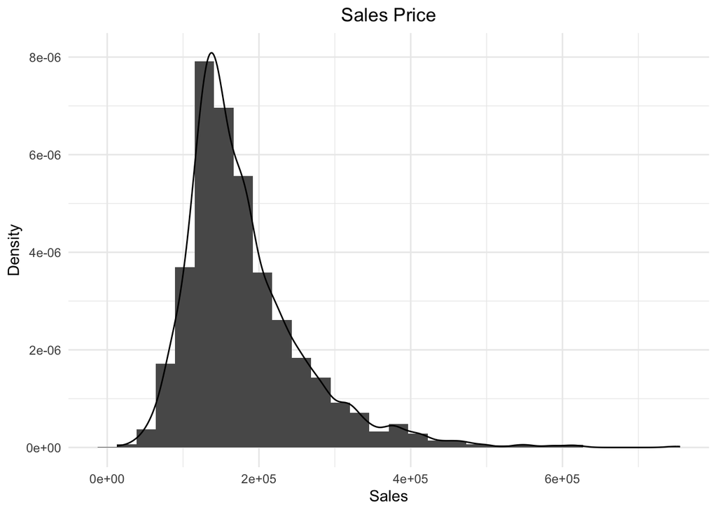

```r
ames_df %>%
  ggplot(aes(Sale_Price, ..density..)) +
  geom_histogram(bins = 30) +
  geom_density() +
  labs(x = "Sales", y = "Density") +
  theme_minimal() +
  theme(plot.title = element_text(hjust = 0.5)) +
  ggtitle("Sales Price")
```

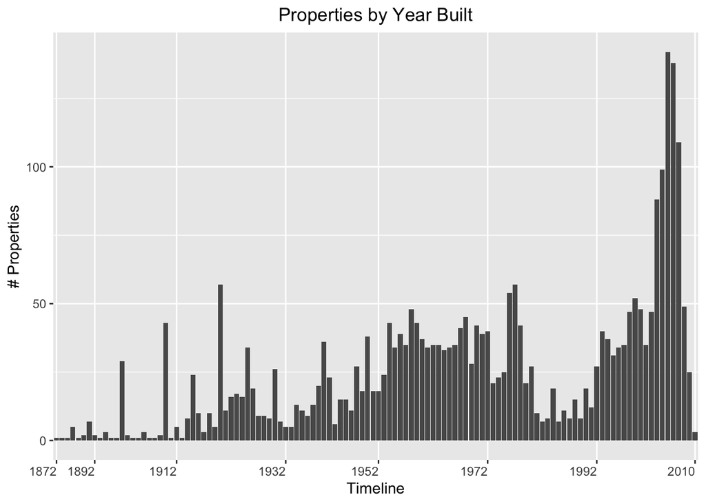

```r
# Determine the minimum and maximum year
min_year <- min(ames_df$Year_Built)
max_year <- max(ames_df$Year_Built)

# Create breaks every 20 years from min to max
breaks <- c(seq(min_year, max_year, by = 20), max_year)

ggplot(ames_df, aes(x = factor(Year_Built))) +
  geom_bar() +
  labs(x = "Timeline", y = "# Properties") +
  scale_x_discrete(breaks = breaks, labels = breaks) +
  theme(axis.text.x = element_text(hjust = 1),
        plot.title = element_text(hjust = .5)) +
  ggtitle("Properties by Year Built")
```

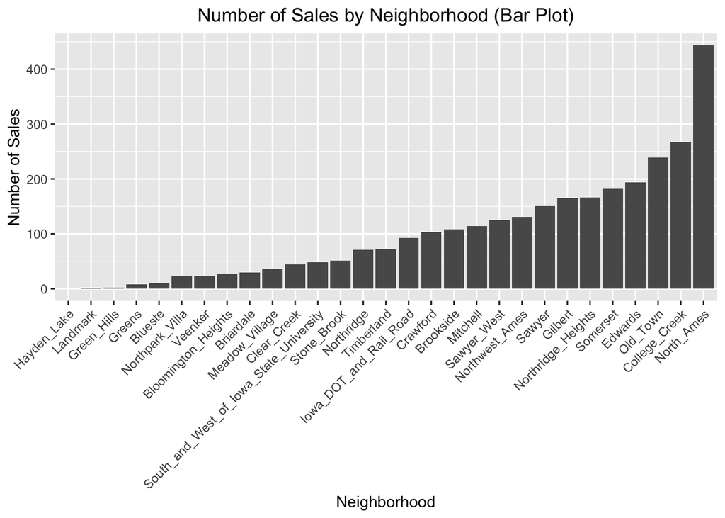

```r
# Count the number of sales by neighborhood
neighborhood_counts <- table(ames_df$Neighborhood)

# Convert the counts to a data frame
neighborhood_counts_df <- as.data.frame(neighborhood_counts)
names(neighborhood_counts_df) <- c("Neighborhood", "Sales_Count")

# Sort the data frame by sales count
neighborhood_counts_df <- neighborhood_counts_df[order(-neighborhood_counts_df$Sales_Count),]

# Bar plot
ggplot(neighborhood_counts_df, aes(x = reorder(Neighborhood, Sales_Count), y = Sales_Count)) +
  geom_bar(stat = "identity") +
  labs(x = "Neighborhood", y = "Number of Sales") +
  theme(axis.text.x = element_text(angle = 45, hjust = 1),
        plot.title = element_text(hjust = .5)) +
  ggtitle("Number of Sales by Neighborhood (Bar Plot)")
```

This last graph graph shows the variation of prices on each neighborhood

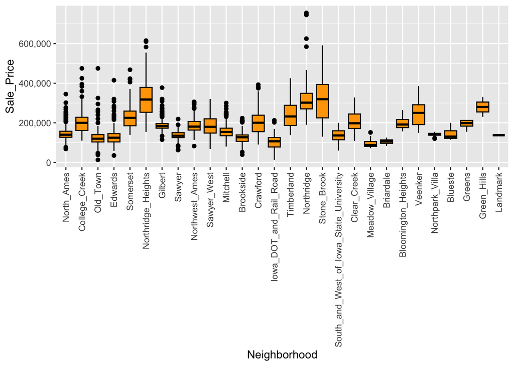

```r
ggplot(ames_df, aes(x=Neighborhood,y=Sale_Price)) + geom_boxplot(color="black", fill="orange")+
theme(axis.text.x = element_text(angle = 90, vjust = 0.5, hjust=1))+
scale_y_continuous(labels = comma)
```

# Reression Model

## Create a price prediction model using Decision Tree

First step is to split into **train** and **test** the dataset, using a seed to work with the same results always

```r
set.seed(123)
split_initial <- initial_split(data = ames_df,
              prop = 0.8, # training proportion
              strata = Sale_Price, # Variable objetivo
              # hace el split lo más distribuido del precio automaticamente
              )

data_train <- training(split_initial)
data_test <- testing(split_initial)
```

Next step is to apply the **recipe** and create a transformation, should be applied to both, train and test datasets.

```r
transformer <- recipe(formula = Sale_Price ~.,
        data = data_train) |>
        step_naomit(all_predictors()) |>
        step_nzv(all_predictors()) |>
        step_center(all_numeric(), -all_outcomes()) |>
        step_scale(all_numeric(), -all_outcomes()) |>
        step_dummy(all_nominal(), -all_outcomes())

transformer_fit <- prep(transformer)

data_train_prep <- bake(transformer_fit, new_data = data_train)
data_test_prep <- bake(transformer_fit, new_data = data_test)
```